# Assignment_9

Carlos Nunez

11/1/2020

## Introduction

The main purpose of this analysis was to observe the interactions between GPA, GRE, and School Rank, and how they affect the probability of a student being admitted into graduate school.

Several models were built using the function stepAIC(). stepAIC() works by trying all possible interactions of the different variables provided from a sample model. Two sample models were used, models 1 and 2. A step$formula was used to help find the best model generated. Furthermore summary and residuals tests were performed on both models.The aim was to find the simplest and best model for explaining the variables and their affects on a student’s chances of being admitted into graduate school. Models 3 and 4 were built used he stepAIC() function, and were the onces used for the analysis.

Models and stepAIC

```r
#create different logistic regression models/sample models.
model_1 <- glm(data = df,
               formula = admit ~ gpa + gre + rank,
               family = "binomial")

summary(model_1)

model_2 <- glm(data = df,
               formula = admit ~ gpa * gre * rank,
               family = "binomial")
summary(model_2)

#########################################################
#sample models being fed into the stepAIC() to create the optimal models.
step1 <- stepAIC(model_1)
step1$formula #Find the best model


model_3 <- glm(data = df,
              formula = step1$formula)


step2 <- stepAIC(model_2)
step2$formula #Find the best model


model_4 <- glm(data = df,
              formula = step2$formula)
```

The main differences between sample models 1 and 2, is that model 1 is essentially saying admission as a function of gpa and gre and rank, while model 2 is read admission as a function of gpa, gre, rank, and the interactions between gpa and rank, gre and rank, as well as gpa, gre, and rank. Another point to note is that in model 1 only the y-intercept of the model can vary based on the variables given, while in model 2 both y-intercept and slope can vary based on the variables given.

Summary of the Models

```r
# Summary Function

summary(model_3)# Has most significant values for the interaction between the exploratory variables.
```

```
##
## Call:
## glm(formula = step1$formula, data = df)
##
## Deviance Residuals:
##     Min       1Q   Median       3Q      Max
## -0.7022  -0.3288  -0.1922   0.4952   0.9093
##
## Coefficients:
##               Estimate Std. Error t value Pr(>|t|)
## (Intercept) -0.2589102  0.2159904  -1.199   0.2314
## gpa          0.1555350  0.0639618   2.432   0.0155 *
## gre          0.0004296  0.0002107   2.038   0.0422 *
## rank2       -0.1623653  0.0677145  -2.398   0.0170 *
## rank3       -0.2905705  0.0702453  -4.137 4.31e-05 ***
## rank4       -0.3230264  0.0793164  -4.073 5.62e-05 ***
## ---
## Signif. codes:  0 '***' 0.001 '**' 0.01 '*' 0.05 '.' 0.1 ' ' 1
##
## (Dispersion parameter for gaussian family taken to be 0.1979062)
##
##     Null deviance: 86.677  on 399  degrees of freedom
## Residual deviance: 77.975  on 394  degrees of freedom
## AIC: 495.12
##
## Number of Fisher Scoring iterations: 2
```

```r
#It also shows that the rank variable has the most significant statistical significance.
summary(model_4)
```

```
##
## Call:
## glm(formula = step2$formula, data = df)
##
## Deviance Residuals:
##     Min       1Q   Median       3Q      Max
## -0.6417  -0.3323  -0.1978   0.4737   0.9253
##
## Coefficients:
##               Estimate Std. Error t value Pr(>|t|)
## (Intercept) -1.3285677  1.0167676  -1.307   0.1921
## gpa          0.4779514  0.3062338   1.561   0.1194
## gre          0.0022815  0.0017330   1.316   0.1888
## rank2       -0.1684250  0.0679344  -2.479   0.0136 *
## rank3       -0.2901793  0.0702321  -4.132 4.40e-05 ***
## rank4       -0.3289275  0.0794896  -4.138 4.29e-05 ***
## gpa:gre     -0.0005518  0.0005125  -1.077   0.2823
## ---
## Signif. codes:  0 '***' 0.001 '**' 0.01 '*' 0.05 '.' 0.1 ' ' 1
##
## (Dispersion parameter for gaussian family taken to be 0.1978263)
##
##     Null deviance: 86.677  on 399  degrees of freedom
## Residual deviance: 77.746  on 393  degrees of freedom
## AIC: 495.94
##
## Number of Fisher Scoring iterations: 2
```

Residuals of the Models

```r
mean(model_3$residuals^2)
#0.1949
mean(model_4$residuals^2) #model_4 does have a slightly better residual but the differences is insignificant.
#0.1943
```

## Analysis

Once the best model was determined, a prediction’s function was made in order to help give more insight as to how these exploratory variables each affect the probability of being admitted into Graduate School. Plots were created to help visualize how these exploratory variables each affected the probability of being admitted into Graduate School. These plots are shown below.

### Plot 1: Probability of Admission vs GRE

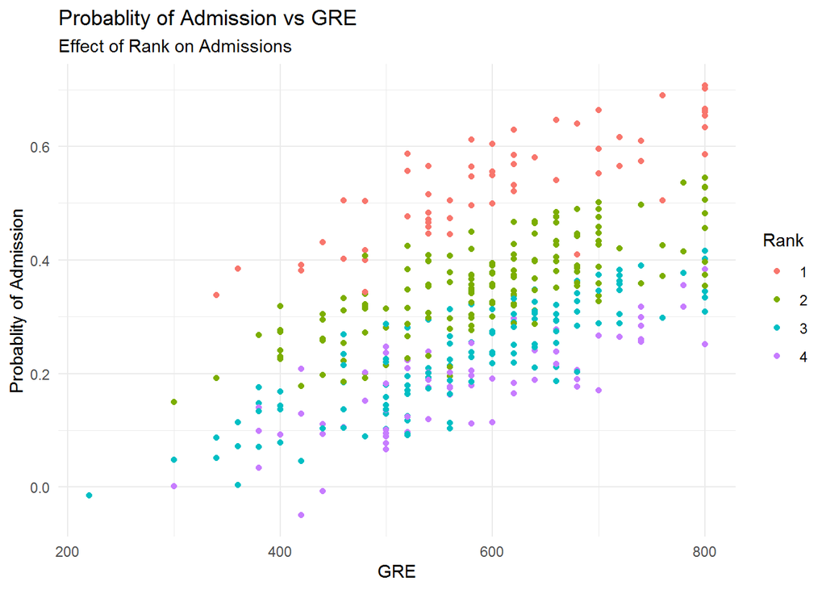

```r
#Once best model found make predictions
df1 <- add_predictions(df, model_3, type = "response")

#Visualize the data and look at the different relationships each exploratory variable has with admit
ggplot(df1, aes(x=gre, y=pred, color = rank))+
  geom_point()+
  theme_minimal()+
  labs(title = "Probablity of Admission vs GRE",subtitle = "Effect of Rank on Admissions",
       x ="GRE", y= "Probablity of Admission", color = "Rank")
```

### Plot 2: Probability of Admission vs GPA

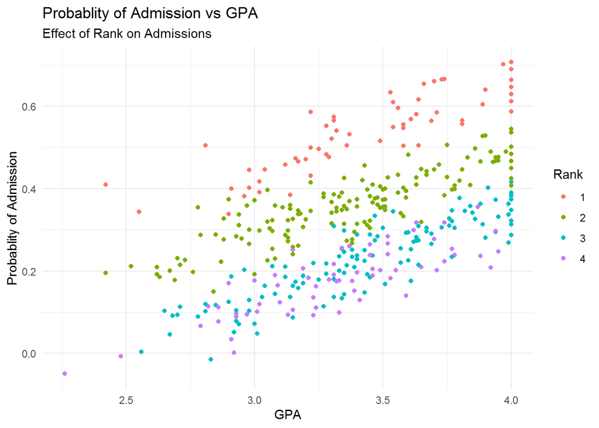

```r
ggplot(df1, aes(x=gpa, y=pred, color = rank))+
  geom_point()+
  theme_minimal()+
  labs(title = "Probablity of Admission vs GPA",subtitle = "Effect of Rank on Admissions",
       x ="GPA", y= "Probablity of Admission", color = "Rank")
```

# Conclusion

In conclusion all three variables are significant in determining the probability that a student will be accepted into graduate school. It was observed that Rank as also noted in the summary function had a strong influence on the probability of being admitted into graduate school regardless of the GPA or GRE score that the student earned.